# DA5020 – Assignment 11

```r
library(tidyverse)
library(class)
library(Hmisc)
library(caret)
```

#### Question 1 - (5 pts) Load the diabetes dataset “diabetes.csv”, view the dimensions of the data, and gather summary statistics.

```r
diabetes <- read_csv("diabetes.csv")
dim(diabetes)
```

```
[1] 768   9
```

```r
describe(diabetes)
```

```
diabetes

 9  Variables      768  Observations
-----------------------------------------------------------------------------------------------
Pregnancies
       n  missing distinct     Info     Mean      Gmd      .05      .10      .25      .50
     768        0       17    0.986    3.845    3.698        0        0        1        3
     .75      .90      .95
       6        9       10

lowest :  0  1  2  3  4, highest: 12 13 14 15 17

Value          0     1     2     3     4     5     6     7     8     9    10    11    12    13
Frequency    111   135   103    75    68    57    50    45    38    28    24    11     9    10
Proportion 0.145 0.176 0.134 0.098 0.089 0.074 0.065 0.059 0.049 0.036 0.031 0.014 0.012 0.013

Value         14    15    17
Frequency      2     1     1
Proportion 0.003 0.001 0.001
-----------------------------------------------------------------------------------------------
Glucose
       n  missing distinct     Info     Mean      Gmd      .05      .10      .25      .50
     768        0      136        1    120.9    35.48     79.0     85.0     99.0    117.0
     .75      .90      .95
   140.2    167.0    181.0

lowest :   0  44  56  57  61, highest: 195 196 197 198 199
-----------------------------------------------------------------------------------------------
BloodPressure
       n  missing distinct     Info     Mean      Gmd      .05      .10      .25      .50
     768        0       47    0.998    69.11    18.81     38.7     54.0     62.0     72.0
     .75      .90      .95
    80.0     88.0     90.0

lowest :   0  24  30  38  40, highest: 106 108 110 114 122
-----------------------------------------------------------------------------------------------
SkinThickness
       n  missing distinct     Info     Mean      Gmd      .05      .10      .25      .50
     768        0       51    0.974    20.54    17.93        0        0        0       23
     .75      .90      .95
```

[output cut: 26 more lines]

```
lowest : 0.078 0.084 0.085 0.088 0.089, highest: 1.893 2.137 2.288 2.329 2.420
-----------------------------------------------------------------------------------------------
Age
       n  missing distinct     Info     Mean      Gmd      .05      .10      .25      .50
     768        0       52    0.998    33.24    12.62       21       22       24       29
     .75      .90      .95
      41       51       58

lowest : 21 22 23 24 25, highest: 68 69 70 72 81
-----------------------------------------------------------------------------------------------
Outcome
       n  missing distinct     Info      Sum     Mean      Gmd
     768        0        2    0.682      268    0.349    0.455

-----------------------------------------------------------------------------------------------
```

#### Question 1.2 - (10 pts) Normalize the explanatory variables using min-max normalization.

```r
diabetes_norm <-
  diabetes %>%
  mutate_at(c(1:ncol(.) - 1), function(x)(x - min(x)) / (max(x) - min(x)))
head(diabetes_norm)
```

| Pregnancies | Glucose | BloodPressure | SkinThickness | Insulin | BMI | DiabetesPedigreeFunction | Age | Outcome |
| --- | --- | --- | --- | --- | --- | --- | --- | --- |
| 0.35294118 | 0.7437186 | 0.5901639 | 0.3535354 | 0.0000000 | 0.5007452 | 0.23441503 | 0.4833333 | 1 |
| 0.05882353 | 0.4271357 | 0.5409836 | 0.2929293 | 0.0000000 | 0.3964232 | 0.11656704 | 0.1666667 | 0 |
| 0.47058824 | 0.9195980 | 0.5245902 | 0.0000000 | 0.0000000 | 0.3472429 | 0.25362938 | 0.1833333 | 1 |
| 0.05882353 | 0.4472362 | 0.5409836 | 0.2323232 | 0.1111111 | 0.4187779 | 0.03800171 | 0.0000000 | 0 |
| 0.00000000 | 0.6884422 | 0.3278689 | 0.3535354 | 0.1985816 | 0.6423249 | 0.94363792 | 0.2000000 | 1 |
| 0.29411765 | 0.5829146 | 0.6065574 | 0.0000000 | 0.0000000 | 0.3815201 | 0.05251921 | 0.1500000 | 0 |

#### Question 1.3 - (5 pts) Split the data into a training set and a test set i.e. perform an 80/20 split; 80% training data and 20% test data

```r
## reproducible
set.seed(82)

## shuffle rows
diabetes_norm  <- diabetes_norm[sample(nrow(diabetes_norm)),]

## subset top 80%
diabetes_train <- diabetes_norm %>% slice(1:(0.8*n()))

## subset bottom 20%
diabetes_test  <- diabetes_norm %>% slice((0.8*n()) + 1:n())

diabetes_train <- diabetes_norm %>% slice(1:(0.8*n()))
diabetes_test  <- diabetes_norm %>% slice((0.8*n()):n())

dim(diabetes_train)
```

```
[1] 614   9
```

```r
dim(diabetes_test)
```

```
[1] 154   9
```

#### Question 1.4 - (0 pts) Using the two datasets from (3) above, separate the explanatory variables from the response variable and assign them to new variables — i.e create variables called train.data and train.data.labels which contain the training data and its labels respectively; and create test.data and test.data.labels which contain the test data and its labels respectively.

```r
train.data        <- diabetes_train %>% select(-one_of("Outcome"))
train.data.labels <- diabetes_train %>% select(Outcome)

test.data         <- diabetes_test %>% select(-one_of("Outcome"))
test.data.labels  <- diabetes_test %>% select(Outcome)
```

#### Question 1.5a - (10 pts) Use the knn() function from the class library, and provide the following as input: the training set, the test set; the labels for the training data and the value of k (use the square root of the number of observations). For example knn(train= train.data, test= test.data, cl= train.data.labels, k=value).

```r
knn_predict <-
  knn(
  train = as.matrix(train.data),
  test  = test.data,
  cl    = as.matrix(train.data.labels),
  k     = sqrt(nrow(train.data))
)
test_data_prediction <-
  test.data %>%
  cbind(test.data.labels,
        knn_predict
          ) %>%
  tibble() %>% mutate(knn_predict = as.numeric(
    as.character(
      knn_predict
    )))

head(test_data_prediction)
```

| Pregnancies | Glucose | BloodPressure | SkinThickness | Insulin | BMI | DiabetesPedigreeFunction | Age | Outcome | knn_predict |
| --- | --- | --- | --- | --- | --- | --- | --- | --- | --- |
| 0.5294118 | 0.6180905 | 0.5737705 | 0.4444444 | 0.1111111 | 0.4932936 | 0.12638770 | 0.31666667 | 0 | 1 |
| 0.1764706 | 0.5125628 | 0.3606557 | 0.2020202 | 0.1111111 | 0.4590164 | 0.13748933 | 0.08333333 | 0 | 0 |
| 0.7647059 | 0.5226131 | 0.5901639 | 0.0000000 | 0.0000000 | 0.4649776 | 0.16524338 | 0.28333333 | 1 | 0 |
| 0.3529412 | 0.4824121 | 0.0000000 | 0.0000000 | 0.0000000 | 0.3532042 | 0.04782237 | 0.11666667 | 0 | 0 |
| 0.4117647 | 0.7638191 | 0.7213115 | 0.4444444 | 0.0000000 | 0.7451565 | 0.11058924 | 0.25000000 | 1 | 1 |
| 0.1764706 | 0.5678392 | 0.4098361 | 0.1010101 | 0.1004728 | 0.4396423 | 0.23398804 | 0.06666667 | 0 | 0 |

#### Question 1.5b - (10 pts) Evaluate the predictions using a confusion matrix, to determine how accurate the model predicted the labels. Explain the results. Note: see reference in the ‘Useful Resources’ section for more information on building a confusion matrix in R.

```r
table(test_data_prediction[, 9:10])
```

```
       knn_predict
Outcome  0  1
      0 93  9
      1 25 27
```

```r
confusionMatrix(test_data_prediction[, 9] %>% pull() %>% as.factor(),
                test_data_prediction[, 10] %>% pull() %>% as.factor())
```

```
Confusion Matrix and Statistics

          Reference
Prediction  0  1
         0 93  9
         1 25 27

               Accuracy : 0.7792
                 95% CI : (0.7054, 0.842)
    No Information Rate : 0.7662
    P-Value [Acc > NIR] : 0.3937

                  Kappa : 0.4662

 Mcnemar's Test P-Value : 0.0101

            Sensitivity : 0.7881
            Specificity : 0.7500
         Pos Pred Value : 0.9118
         Neg Pred Value : 0.5192
             Prevalence : 0.7662
         Detection Rate : 0.6039
   Detection Prevalence : 0.6623
      Balanced Accuracy : 0.7691

       'Positive' Class : 0
```

The model produced 120 accurate predictions (true positives/negatives) and 34 inaccurate predictions (false positive/negatives.) The confusion matrix indicates an accuracy rate of 77%.

#### Question 1.6 - (20 pts) Repeat step 5: perform an experiment to find the best value of k. Ensure that you use at least 5 different values of k and display the results i.e. the corresponding model and its output. Which model produced the best results?

```r
## try k = c(2:12)
lapply(c(2:12), function(x) {
  knn_predict <-
    knn(
      train = as.matrix(train.data),
      test  = test.data,
      cl    = as.matrix(train.data.labels),
      k     = x
    )
  test_data_prediction <-
    test.data %>%
    cbind(test.data.labels,
          knn_predict
    ) %>%
    tibble() %>% mutate(knn_predict = as.numeric(
      as.character(
        knn_predict
      )))

  return(list(
    paste0("Confusion matrix for k = ", x),
    confusionMatrix(test_data_prediction[, 9] %>% pull() %>% as.factor(),
                    test_data_prediction[, 10] %>% pull() %>% as.factor())[2:3]
  ))
})
```

```
[[1]]
[[1]][[1]]
[1] "Confusion matrix for k = 2"

[[1]][[2]]
[[1]][[2]]$table
          Reference
Prediction  0  1
         0 85 17
         1 27 25

[[1]][[2]]$overall
      Accuracy          Kappa  AccuracyLower  AccuracyUpper   AccuracyNull AccuracyPValue
     0.7142857      0.3296399      0.6360181      0.7841067      0.7272727      0.6783383
 McnemarPValue
     0.1748444



[[2]]
[[2]][[1]]
[1] "Confusion matrix for k = 3"

[[2]][[2]]
[[2]][[2]]$table
          Reference
Prediction  0  1
         0 91 11
         1 25 27

[[2]][[2]]$overall
      Accuracy          Kappa  AccuracyLower  AccuracyUpper   AccuracyNull AccuracyPValue
    0.76623377     0.44045216     0.69135103     0.83058466     0.75324675     0.39528660
 McnemarPValue
    0.03026028



[[3]]
[[3]][[1]]
```

[output cut: 151 more lines]

```
[[11]][[1]]
[1] "Confusion matrix for k = 12"

[[11]][[2]]
[[11]][[2]]$table
          Reference
Prediction  0  1
         0 89 13
         1 24 28

[[11]][[2]]$overall
      Accuracy          Kappa  AccuracyLower  AccuracyUpper   AccuracyNull AccuracyPValue
     0.7597403      0.4334858      0.6843656      0.8248454      0.7337662      0.2645355
 McnemarPValue
     0.1001783
```

Among the tested values for K, none result in a significant increase in prediction accuracy. T model with k = 3 yields the highest accuracy (76.6%), but this is still slightly lower than the original model using k = sqrt(nrow(train.data))

#### Question 2.1 - (10 pts) Load the Body Mass Index (BMI) dataset “500_Person_Gender_Height_Weight_Index.csv”. Inspect the explanatory variables and create dummy codes for the categorical variable(s) and normalize the numeric variables using min-max normalization.

```r
bmi <- read_csv("500_Person_Gender_Height_Weight_Index.csv")
bmi_norm <-
  bmi %>%

  ## 1 for male, 0 for female
  mutate(Gender = if_else(Gender == "Male", 1, 0)) %>%

  ## normalize
  mutate_at(c(2:3), function(x)(x - min(x)) / (max(x) - min(x)))

bmi_norm %>% head()
```

| Gender | Height | Weight | Index |
| --- | --- | --- | --- |
| 1 | 0.5762712 | 0.4181818 | 4 |
| 1 | 0.8305085 | 0.3363636 | 2 |
| 0 | 0.7627119 | 0.5454545 | 4 |
| 0 | 0.9322034 | 0.4909091 | 3 |
| 1 | 0.1525424 | 0.1000000 | 3 |
| 1 | 0.8305085 | 0.4909091 | 3 |

#### Question 2.2 - (5 pts) Split the data into a training set and a test set i.e. perform an 80/20 split; 80% training data and 20% test data.

```r
## reproducible
set.seed(5020)

## shuffle rows
bmi  <- bmi[sample(nrow(bmi)),]

## subset 80%
bmi_train <- bmi_norm %>% slice(1:(0.8*n()))

## subset 20%
bmi_test  <- bmi_norm %>% slice((0.8*n()) + 1:n())

dim(bmi_train)
```

```
[1] 400   4
```

```r
dim(bmi_test)
```

```
[1] 100   4
```

#### Question 2.3 - (0 pts) Separate the explanatory variables from the response variable and assign them to new variables (similar to Q1.4 above).

```r
bmi_train_data   <- bmi_train %>% select(-one_of("Index"))
bmi_train_labels <- bmi_train %>% select(Index)

bmi_test_data    <- bmi_test %>% select(-one_of("Index"))
bmi_test_labels  <- bmi_test %>% select(Index)
```

#### Question 2.4 - (15 pts) Build the k-NN model using the variables in (3) and evaluate the predictions — experiment with different values of k to identify the best model.

```r
## try k = c(2 - 12)
lapply(c(2:12), function(x) {
  knn_predict <-
    knn(
      train = as.matrix(bmi_train_data),
      test  = bmi_test_data,
      cl    = bmi_train_labels %>% pull() %>% as.factor(),
      k     = x
    )
  test_data_prediction <-
    bmi_test_data %>%
    cbind(bmi_test_labels,
          knn_predict
    ) %>%
    tibble() %>% mutate(knn_predict = as.numeric(
      as.character(
        knn_predict
      )))

  return(list(
    paste0("Confusion matrix for k = ", x),

    ## only return the confusion matrix and accuracy information
    ## in order to minimize output
    confusionMatrix(test_data_prediction %>% pull(knn_predict) %>% as.factor(),
                    test_data_prediction %>% pull(Index) %>% as.factor())[2:3]
  ))
})
```

```
[[1]]
[[1]][[1]]
[1] "Confusion matrix for k = 2"

[[1]][[2]]
[[1]][[2]]$table
          Reference
Prediction  0  1  2  3  4  5
         0  2  0  1  0  0  0
         1  0  4  1  0  0  0
         2  0  3  9  0  1  0
         3  0  0  5  2  1  0
         4  0  0  0  2 20  3
         5  0  0  0  0  4 42

[[1]][[2]]$overall
      Accuracy          Kappa  AccuracyLower  AccuracyUpper   AccuracyNull AccuracyPValue
  7.900000e-01   6.999571e-01   6.970846e-01   8.650563e-01   4.500000e-01   3.669368e-12
 McnemarPValue
           NaN



[[2]]
[[2]][[1]]
[1] "Confusion matrix for k = 3"

[[2]][[2]]
[[2]][[2]]$table
          Reference
Prediction  0  1  2  3  4  5
         0  1  1  0  0  0  0
         1  1  3  1  0  0  0
         2  0  3 12  0  0  0
         3  0  0  3  3  0  1
         4  0  0  0  1 23  2
         5  0  0  0  0  3 42

[[2]][[2]]$overall
      Accuracy          Kappa  AccuracyLower  AccuracyUpper   AccuracyNull AccuracyPValue
```

[output cut: 195 more lines]

```
[[11]][[2]]$table
          Reference
Prediction  0  1  2  3  4  5
         0  1  1  0  0  0  0
         1  1  3  1  0  0  0
         2  0  3  9  0  0  0
         3  0  0  5  3  1  0
         4  0  0  1  1 21  2
         5  0  0  0  0  4 43

[[11]][[2]]$overall
      Accuracy          Kappa  AccuracyLower  AccuracyUpper   AccuracyNull AccuracyPValue
  8.000000e-01   7.129736e-01   7.081573e-01   8.733444e-01   4.500000e-01   7.758440e-13
 McnemarPValue
           NaN
```

The most accurate predictions arise from using k = 4 which produces an overall accuracy of 88%

#### Question 2.5 - (10 pts) Create a data frame with at least 5 new observations (i.e. comprising the gender, weight and height) that you will use to test your model. Predict the body mass index i.e Index for the sample data and comment on the predictions (did they align with your expectations?).

```r
set.seed(2020)

weights <- runif(5, 80, 150) %>% round()
heights <- runif(5, 140, 180) %>% round()

bmi_test_tbl <-
  tibble(
  "Gender" = c( 0, 1, 0, 1, 1),   ## 1 == male, 0 == female
  "Weight" = weights,
  "Height" = heights
) %>% mutate_at(c(2:3), function(x)(x - min(x)) / (max(x) - min(x)))
knn_predict_index <-
    knn(
      train = as.matrix(bmi_train_data),
      test  = bmi_test_tbl,
      cl    = as.matrix(bmi_train_labels),
      k     = 4 ## k = 4 is predicted to have the highest accuracy at 88%
    )
  bmi_data_prediction <-
    cbind(bmi_test_tbl,
          knn_predict_index)

  bmi_data_prediction <- bmi_data_prediction %>%
    mutate(Weight_num = weights,
           Height_num = heights)
  bmi_data_prediction
```

| Gender | Weight | Height | knn_predict_index | Weight_num | Height_num |
| --- | --- | --- | --- | --- | --- |
| 0 | 1.0000000 | 0.12 | 1 | 125 | 143 |
| 1 | 0.5142857 | 0.20 | 3 | 108 | 145 |
| 0 | 0.9428571 | 0.64 | 3 | 123 | 156 |
| 1 | 0.6571429 | 0.00 | 1 | 113 | 140 |
| 1 | 0.0000000 | 1.00 | 5 | 90 | 165 |

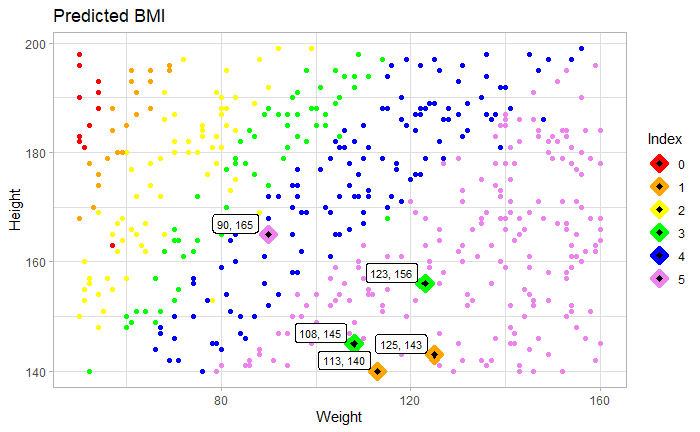

```r
bmi %>%
  ggplot(aes(
    x = Weight,
    y = Height)) +
  geom_point(aes(color = as.factor(Index))) +
  labs(title = "Predicted BMI") +
  guides(color = guide_legend(title = "Index")) +
  theme_light() +
  geom_point(
    data = bmi_data_prediction,
    aes(
      color = as.factor(knn_predict_index),
        x     = Weight_num,
        y     = Height_num),
    pch    = 23,
    fill   = "black",
    size   = 2,
    stroke = 3) +
  annotate(geom  = "label",
           x     = bmi_data_prediction$Weight_num - 7,
           y     = bmi_data_prediction$Height_num + 2,
           label = paste0(round(bmi_data_prediction$Weight_num), ", ",
                          round(bmi_data_prediction$Height_num)),
           fill  = "white",
           size  = 3) +
  scale_colour_manual(values = c("red", "orange", "yellow",
                                 "green", "blue", "violet"))
```

None of the predictions appear to be correct, which does not agree with the expected accuracy of 88%.

#### Question 3.1 - (10 pts) Classification versus regression: clearly explain each term and provide examples.

A classification model will have a categorized output of discrete groups. In this assignment, the numeric indices are used as categorical variables to represent which ‘bin’ an individual will be placed into based on height and weight.  
Conversely, a regression model produces a continuous value (non-categorical) which can be represented on a scale. In assignment 10, the BMI outputs were continuous because they were not discrete values, i.e. an output of BMI = 4.3 was possible because the index is computed on a numeric continuum.

#### Question 3.2 - (10 pts) Refer to the BMI exercise in assignment 10 and your solution in Question 2 (above). State your recommendation regarding the best use of the BMI dataset i.e. is more suitable for classification or regression and justify your response.

Based on my own results from assignments 10 and 11, a regression model is more appropriate to calculate BMI, because the BMI scale itself is not a classifying feature with discrete categories. It is a scale and can contain values that are not whole integer bins.